# ANOVA – part 2

Petr Keil

February 2015

The aim of this lesson is to (1) leave the participants to come up with their code for simple one-way ANOVA, and (2) to experiment with random effects ANOVA.

# 1 The Data

We will use modified data from the example from **Marc Kery’s Introduction to WinBUGS for Ecologists**, page 119 (Chapter 9 - ANOVA). The data describe snout-vent lengths in 5 populations of Smooth snake (*Coronella austriaca*) (Uzovka hladka in CZ).

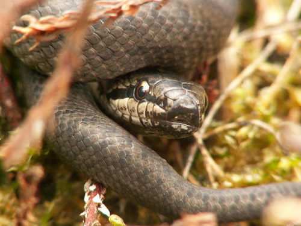

Loading the data from the web:

```r
  snakes <- read.csv("http://www.petrkeil.com/wp-content/uploads/2014/02/snakes.csv")

# we will artificially delete 9 data points in the first population
  snakes <- snakes[-(1:9),]

  summary(snakes)
```

```
##    population     snout.vent
##  Min.   :1.00   Min.   :36.6
##  1st Qu.:2.00   1st Qu.:43.0
##  Median :3.00   Median :49.2
##  Mean   :3.44   Mean   :50.1
##  3rd Qu.:4.00   3rd Qu.:57.6
##  Max.   :5.00   Max.   :61.4
```

Plotting the data:

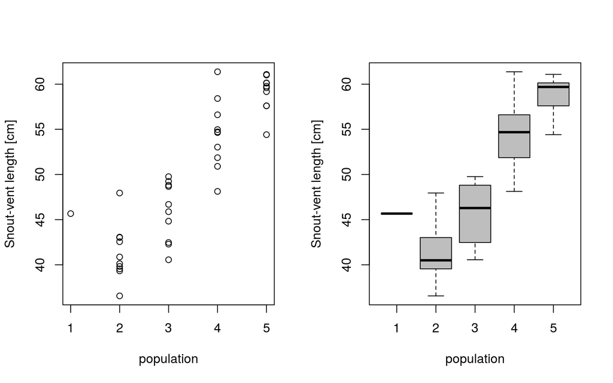

```r
  par(mfrow=c(1,2))
  plot(snout.vent ~ population, data=snakes,
       ylab="Snout-vent length [cm]")
  boxplot(snout.vent ~ population, data=snakes,
          ylab="Snout-vent length [cm]",
          xlab="population",
          col="grey")
```

# 2 Fixed-effects ANOVA

For a given snake $i$ in population $j$ **the model** can be written as:

$y_{ij} \sim Normal(\alpha_j, \sigma)$

Here is how we prepare the data:

```r
  snake.data <- list(y=snakes$snout.vent,
                     x=snakes$population,
                     N=nrow(snakes),
                     N.pop=5)
```

Loading the library that communicates with JAGS

```r
  library(R2jags)
```

JAGS Model definition:

```r
cat("
  model
  {
    # priors
    sigma ~ dunif(0,100)
    tau <- 1/(sigma*sigma)
    for(j in 1:N.pop)
    {
      alpha[j] ~ dnorm(0, 0.001)
    }

    # likelihood
    for(i in 1:N)
    {
      y[i] ~ dnorm(alpha[x[i]], tau)
    }
  }
", file="fixed_anova.txt")
```

And we will fit the model:

```r
model.fit.fix <- jags(data=snake.data,
                        model.file="fixed_anova.txt",
                        parameters.to.save=c("alpha"),
                        n.chains=3,
                        n.iter=2000,
                        n.burnin=1000,
                        DIC=FALSE)
```

```
## module glm loaded
## module dic loaded
```

```
##    Graph Size: 96
##
```

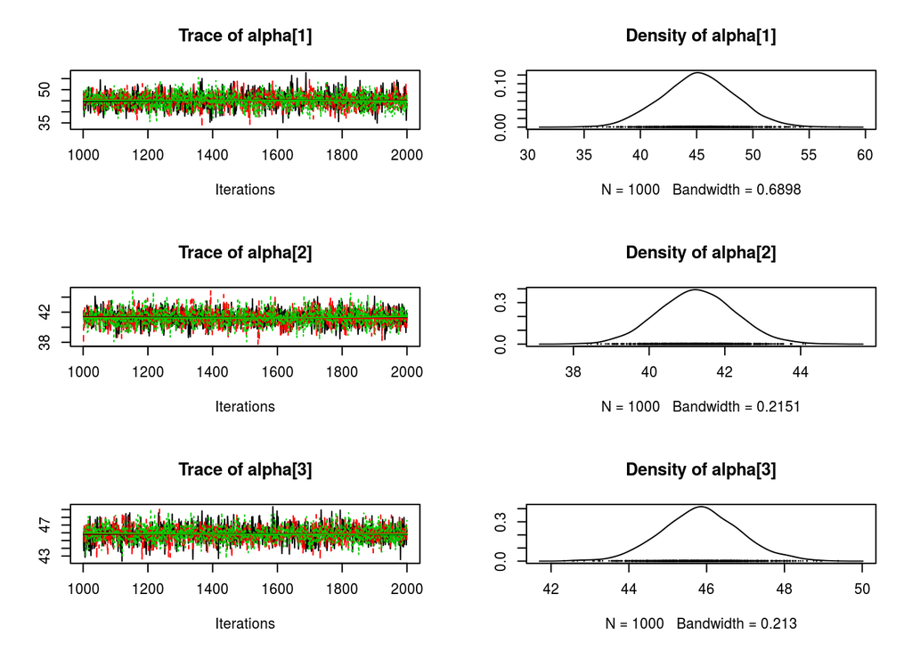

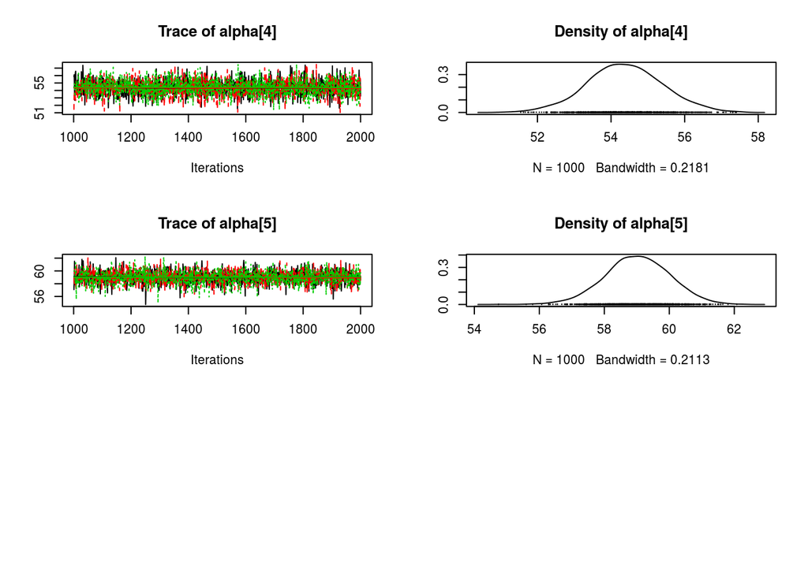

```r
plot(as.mcmc(model.fit.fix))
```

```r
model.fit.fix
```

```
## Inference for Bugs model at "fixed_anova.txt", fit using jags,
##  3 chains, each with 2000 iterations (first 1000 discarded)
##  n.sims = 3000 iterations saved
##          mu.vect sd.vect  2.5%   25%   50%   75% 97.5%  Rhat n.eff
## alpha[1]   45.18   3.272 38.79 43.03 45.15 47.35 51.57 1.001  3000
## alpha[2]   41.26   1.010 39.29 40.58 41.24 41.92 43.25 1.001  3000
## alpha[3]   45.85   1.015 43.91 45.19 45.85 46.52 47.98 1.001  3000
## alpha[4]   54.38   1.027 52.34 53.69 54.36 55.05 56.46 1.002  1700
## alpha[5]   59.01   1.001 56.99 58.36 59.02 59.69 60.96 1.001  3000
##
## For each parameter, n.eff is a crude measure of effective sample size,
## and Rhat is the potential scale reduction factor (at convergence, Rhat=1).
```

# 3 Random-effects ANOVA

For a given snake $i$ in population $j$ **the model** can be written in a similar way as for the fixed-effects ANOVA above:

$y_{ij} \sim Normal(\alpha_j, \sigma)$

But now we will also add a **random effect**:

$\alpha_j \sim Normal(\mu, \sigma)$

In short, a **random effect means that the parameters itself come from (are outcomes of) a given distribution**, here it is the Normal.

The data stay the same as in the fixed-effect example above.

Loading the library that communicates with JAGS

```r
  library(R2jags)
```

JAGS Model definition:

```r
cat("
  model
  {
    # priors
    grand.mean ~ dnorm(0, 0.001)
    grand.sigma ~ dunif(0,100)
    grand.tau <- 1/(grand.sigma*grand.sigma)
    group.sigma ~ dunif(0, 100)
    group.tau <- 1/(group.sigma*group.sigma)

    for(j in 1:N.pop)
    {
      alpha[j] ~ dnorm(grand.mean, grand.tau)
    }

    # likelihood
    for(i in 1:N)
    {
      y[i] ~ dnorm(alpha[x[i]], group.tau)
    }
  }
", file="random_anova.txt")
```

And we will fit the model:

```r
model.fit.rnd <- jags(data=snake.data,
               model.file="random_anova.txt",
               parameters.to.save=c("alpha"),
               n.chains=3,
               n.iter=2000,
               n.burnin=1000,
               DIC=FALSE)
```

```
##    Graph Size: 100
##
```

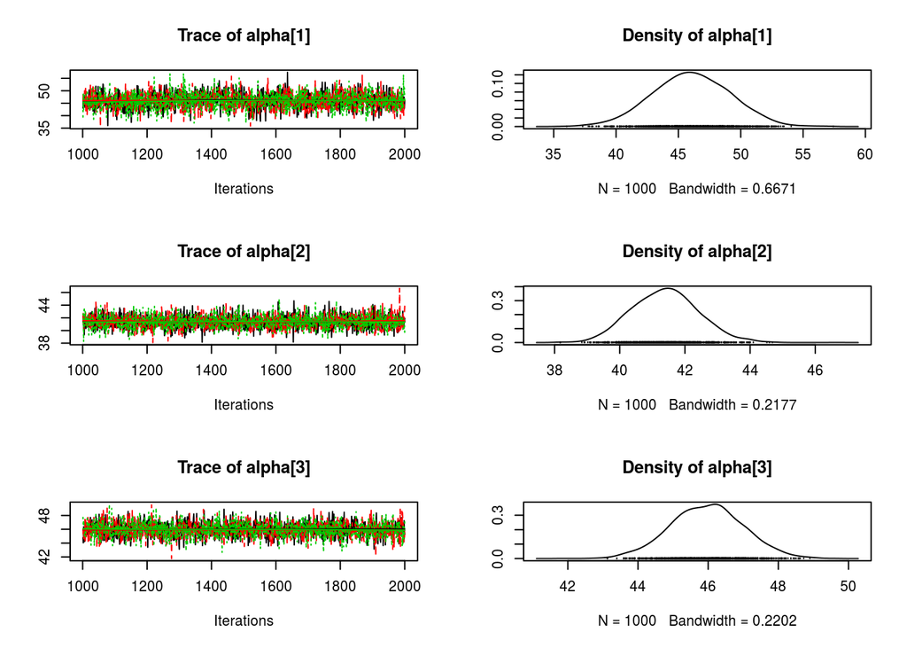

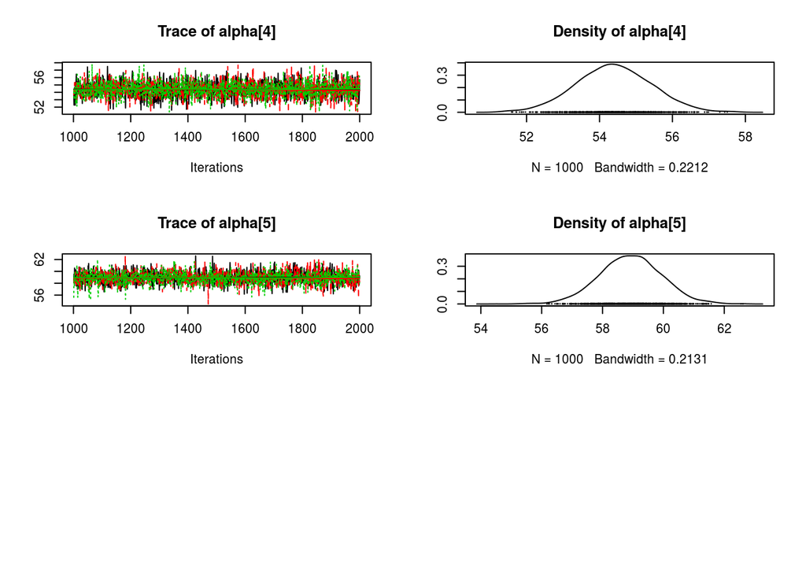

```r
plot(as.mcmc(model.fit.rnd))
```

```r
model.fit.rnd
```

```
## Inference for Bugs model at "random_anova.txt", fit using jags,
##  3 chains, each with 2000 iterations (first 1000 discarded)
##  n.sims = 3000 iterations saved
##          mu.vect sd.vect  2.5%   25%   50%   75% 97.5%  Rhat n.eff
## alpha[1]   46.05   3.121 39.95 43.95 46.02 48.21 52.05 1.001  3000
## alpha[2]   41.40   1.018 39.50 40.69 41.39 42.06 43.45 1.001  3000
## alpha[3]   45.97   1.040 43.91 45.26 45.99 46.64 48.01 1.001  2400
## alpha[4]   54.40   1.035 52.37 53.69 54.38 55.08 56.43 1.001  3000
## alpha[5]   58.92   1.023 56.90 58.24 58.91 59.58 60.90 1.001  3000
##
## For each parameter, n.eff is a crude measure of effective sample size,
## and Rhat is the potential scale reduction factor (at convergence, Rhat=1).
```

# 4 Plotting the posteriors from both models

Let’s extract the medians posterior distributions of the expected values of $\alpha_j$ and their 95% credible intervals:

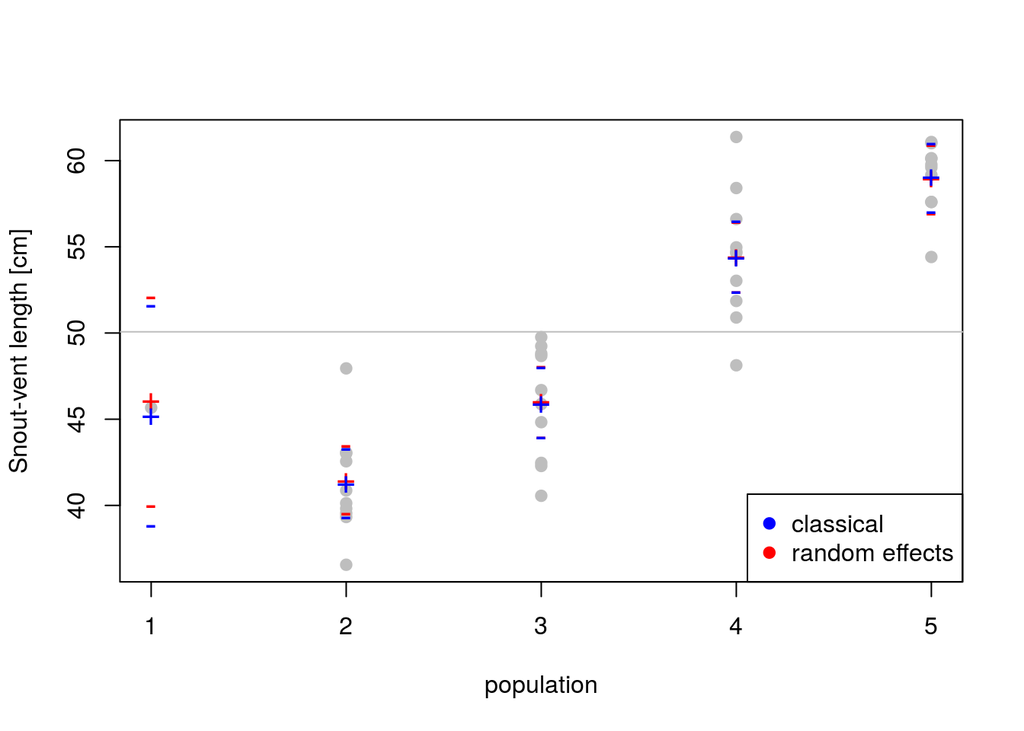

```r
  rnd.alphas <- model.fit.rnd$BUGSoutput$summary
  fix.alphas <- model.fit.fix$BUGSoutput$summary

  plot(snout.vent ~ population, data=snakes,
       ylab="Snout-vent length [cm]", col="grey", pch=19)
  points(rnd.alphas[,'2.5%'], col="red", pch="-", cex=1.5)
  points(fix.alphas[,'2.5%'], col="blue", pch="-", cex=1.5)
  points(rnd.alphas[,'97.5%'], col="red", pch="-", cex=1.5)
  points(fix.alphas[,'97.5%'], col="blue", pch="-", cex=1.5)
  points(rnd.alphas[,'50%'], col="red", pch="+", cex=1.5)
  points(fix.alphas[,'50%'], col="blue", pch="+", cex=1.5)

  abline(h=mean(snakes$snout.vent), col="grey")
  legend("bottomright", pch=c(19,19), col=c("blue","red"),
         legend=c("classical","random effects"))
```

Note the **shrinkage** effect!

Also, how would you plot the `grand.mean` estimated in the random effects model? How would you extract the between- and within- group variances?